# BI PROJECT TRANSCRIPTOME E1A effects

EP

2026-05-19

```r
source("R/functions.R")
```

```r
# List Salmon output
samples <- list.files("../salmon_quant_24/Salmon quant", full.names = TRUE)
files <- file.path(samples, "quant.sf")
names(files) <- basename(samples)
file.exists(files)
```

```
##  [1] TRUE TRUE TRUE TRUE TRUE TRUE TRUE TRUE TRUE TRUE TRUE TRUE TRUE TRUE TRUE
## [16] TRUE TRUE TRUE TRUE TRUE TRUE TRUE TRUE TRUE
```

Imort files and count genes:

```r
tx2gene <- read.csv("../data/tx2gene_symbols.csv")

txi_gene <- tximport(files, type = "salmon", tx2gene = tx2gene, countsFromAbundance="no")
txi_gene_TPM <-  tximport(files, type = "salmon", tx2gene = tx2gene, countsFromAbundance = "lengthScaledTPM")

txi_counts <- data.frame(txi_gene$counts)
txi_TPM <- data.frame(txi_gene_TPM$counts)
write.table(txi_counts, file = "raw_counts_all_samples.txt", sep = "\t", row.names = TRUE, quote = FALSE)
write.csv2(txi_counts, file = "raw_counts_all_samples.csv", row.names = TRUE, quote = FALSE)
write.csv2(txi_TPM, file = "TPM_all_samples.csv", row.names = TRUE, quote = FALSE)
```

Add information about samples

General model for all factors and their interactions

```
## [1] "Intercept"
## [2] "e1a_status_positive_vs_negative"
## [3] "condition_oxpl_vs_ctrl"
## [4] "cell_line_HCT116_oxpl_R_vs_HCT116"
## [5] "e1a_statuspositive.conditionoxpl"
## [6] "e1a_statuspositive.cell_lineHCT116_oxpl_R"
## [7] "conditionoxpl.cell_lineHCT116_oxpl_R"
## [8] "e1a_statuspositive.conditionoxpl.cell_lineHCT116_oxpl_R"
```

```
##
## out of 23860 with nonzero total read count
## adjusted p-value < 0.05
## LFC > 0 (up)       : 17, 0.071%
## LFC < 0 (down)     : 2, 0.0084%
## outliers [1]       : 25, 0.1%
## low counts [2]     : 6014, 25%
## (mean count < 1)
## [1] see 'cooksCutoff' argument of ?results
## [2] see 'independentFiltering' argument of ?results
```

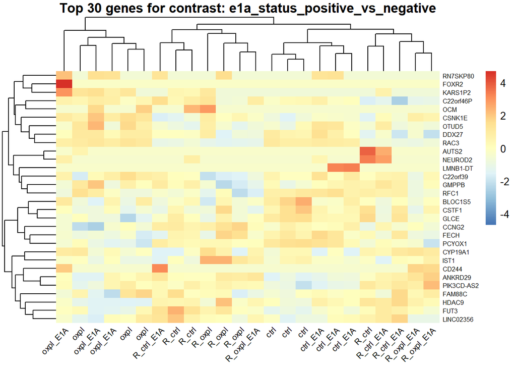

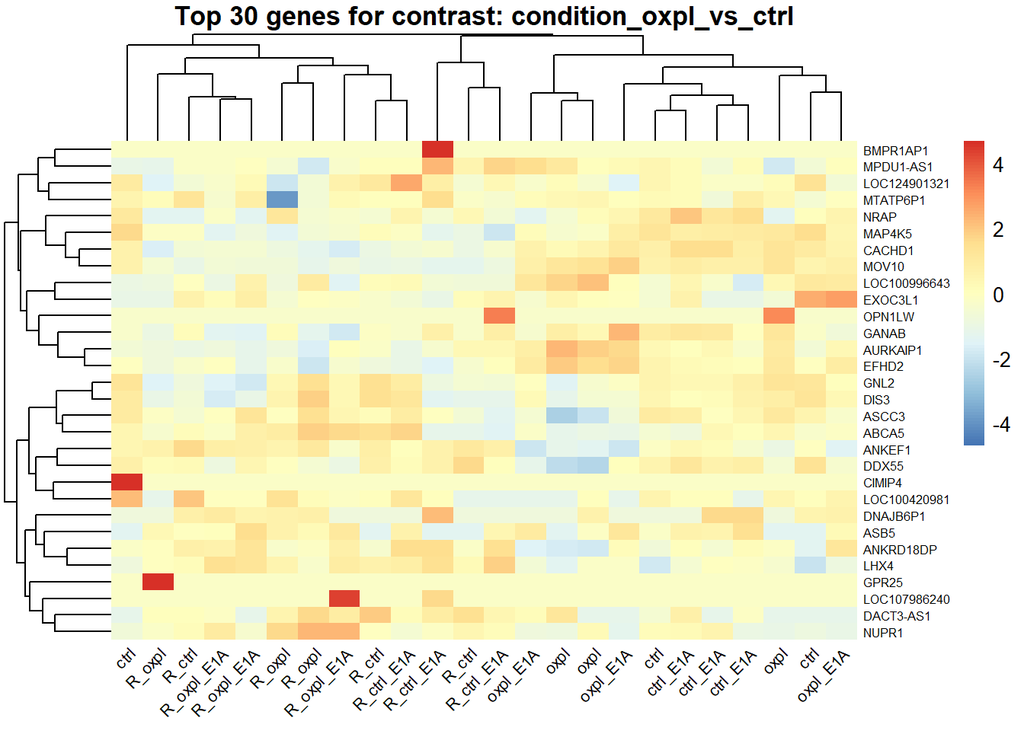

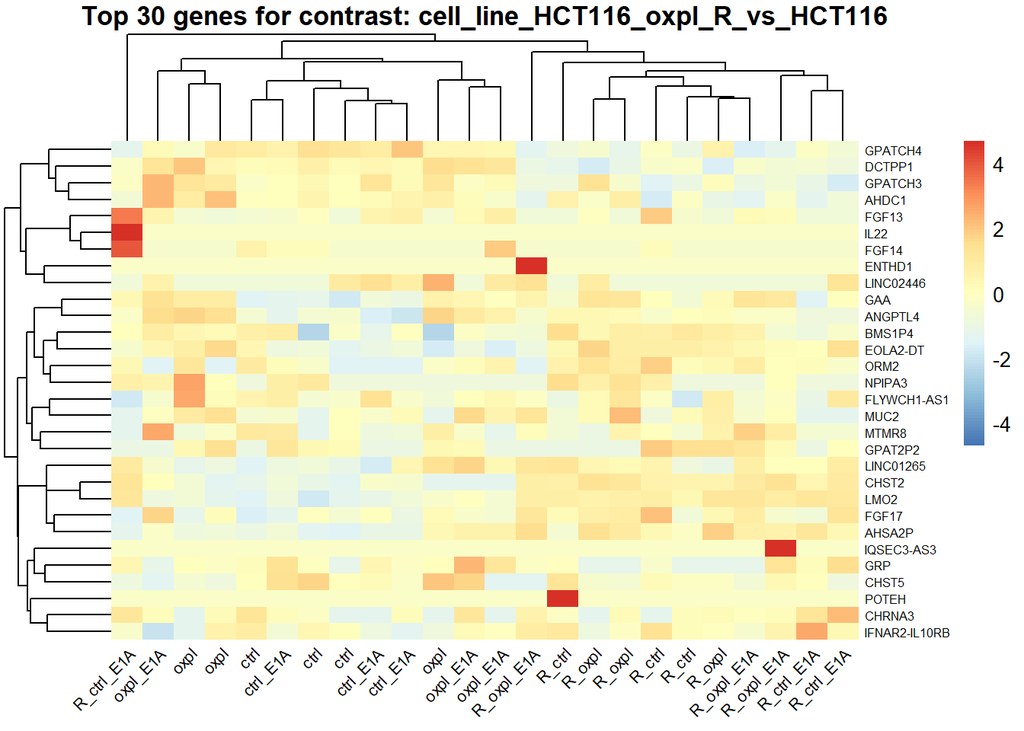

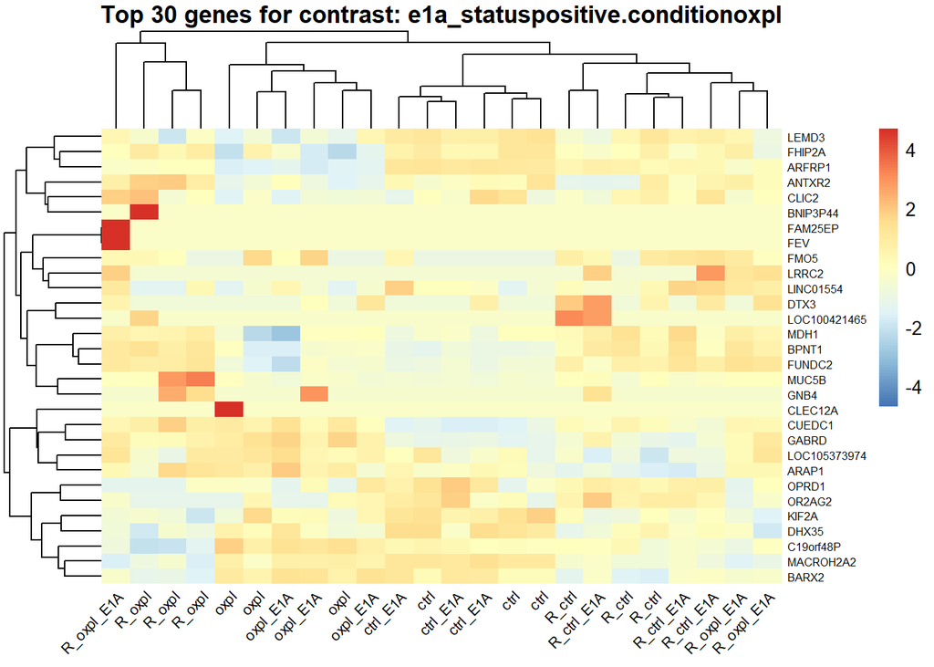

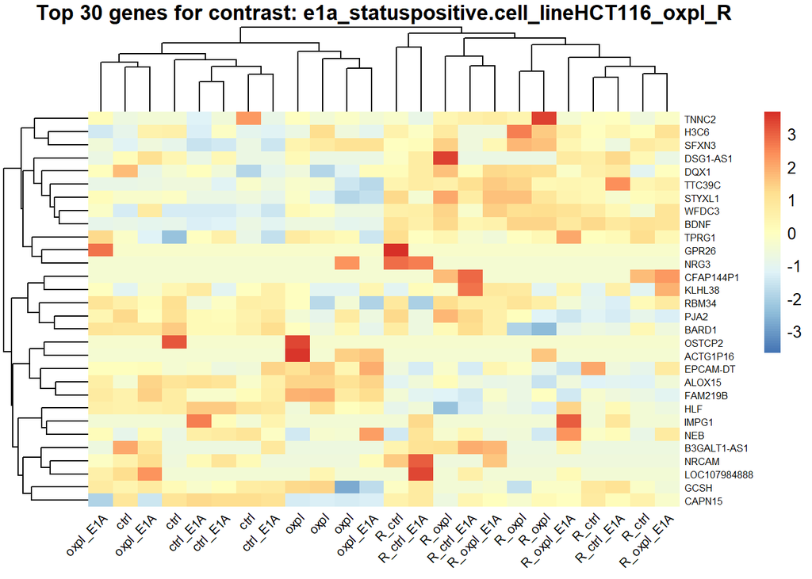

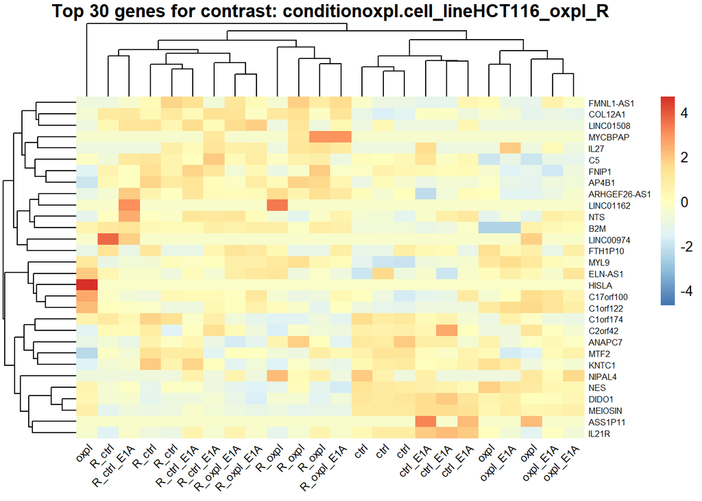

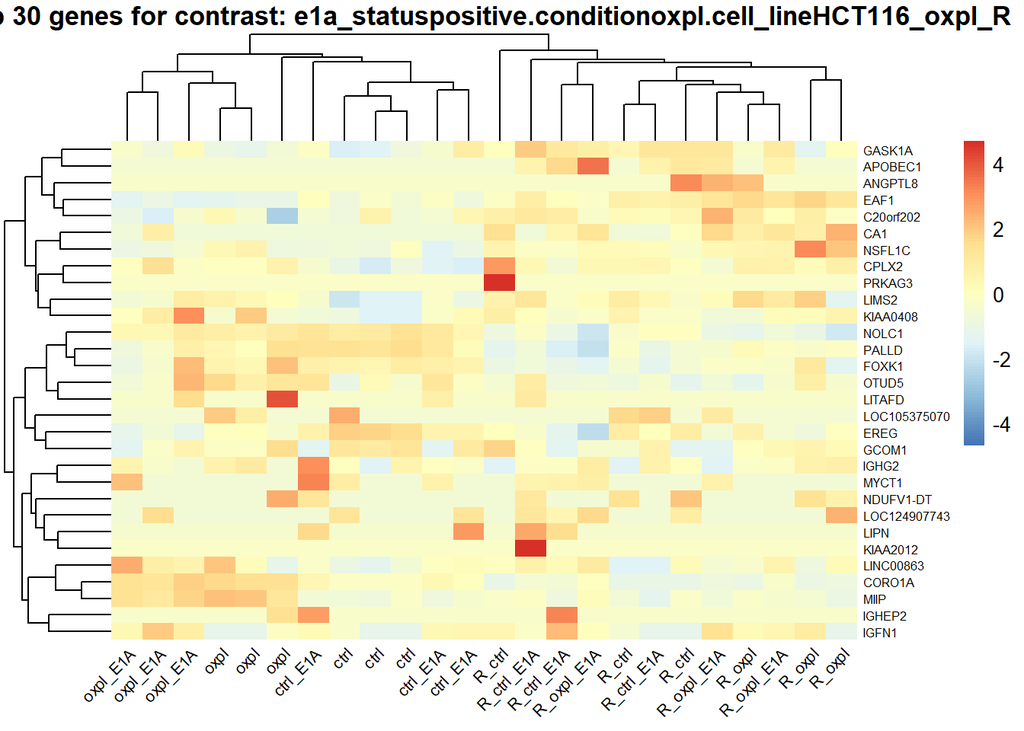

```r
# e1a_status_positive_vs_negative
res_E1A <- results(dds, name = "e1a_status_positive_vs_negative")

summary(res_E1A)
```

```
##
## out of 23860 with nonzero total read count
## adjusted p-value < 0.1
## LFC > 0 (up)       : 234, 0.98%
## LFC < 0 (down)     : 31, 0.13%
## outliers [1]       : 25, 0.1%
## low counts [2]     : 6014, 25%
## (mean count < 1)
## [1] see 'cooksCutoff' argument of ?results
## [2] see 'independentFiltering' argument of ?results
```

```r
res_E1A_df <- as.data.frame(res_E1A)
head(res_E1A_df)
```

```
##            baseMean log2FoldChange     lfcSE       stat      pvalue      padj
## A1BG     11.1263003     -0.9906069 1.4199121 -0.6976537 0.485393802 0.9671648
## A1BG-AS1  0.6230124      1.1444041 4.9888937  0.2293904 0.818565531        NA
## A1CF      1.5189630     -0.7217910 2.2200038 -0.3251305 0.745082299 0.9939676
## A2M      15.8061968     -1.1896294 1.3827518 -0.8603348 0.389604542 0.9413986
## A2M-AS1  12.4853338      0.5782282 0.7936288  0.7285877 0.466253897 0.9624151
## A2ML1     6.3933535      4.2763239 1.5861253  2.6960820 0.007016039 0.2485742
```

```r
# Number of significant genes
sig_genes <- res_E1A[!is.na(res_E1A$padj) & res_E1A$padj < 0.05, ]
total_sig <- nrow(sig_genes)

# Up / Down
up_genes <- sig_genes[sig_genes$log2FoldChange > 0, ]
down_genes <- sig_genes[sig_genes$log2FoldChange < 0, ]

# padj < 0.05 И |log2FC| > 1
sig_genes_fc1 <- res_E1A[!is.na(res_E1A$padj) &
                         res_E1A$padj < 0.05 &
                         abs(res_E1A$log2FoldChange) > 1, ]

up_fc1 <- sig_genes_fc1[sig_genes_fc1$log2FoldChange > 1, ]
down_fc1 <- sig_genes_fc1[sig_genes_fc1$log2FoldChange < -1, ]

cat("Total significant genes:", nrow(sig_genes_fc1), "\n")
```

```
## Total significant genes: 117
```

```r
cat("  - Up (log2FC > 1):", nrow(up_fc1), "\n")
```

```
##   - Up (log2FC > 1): 109
```

```r
cat("  - Down (log2FC < -1):", nrow(down_fc1), "\n")
```

```
##   - Down (log2FC < -1): 8
```

At the threshold of ∣log2FC∣>1, we see 117 significant genes, of which 109 are upregulated and only 8 are downregulated. This is consistent with the fact that E1A causes a powerful transcriptional rearrangement of the cell and, in a number of systems, primarily acts as an activator of expression, although it can simultaneously repress individual pathways through interactions with pRb/E2F and p300/CBP.

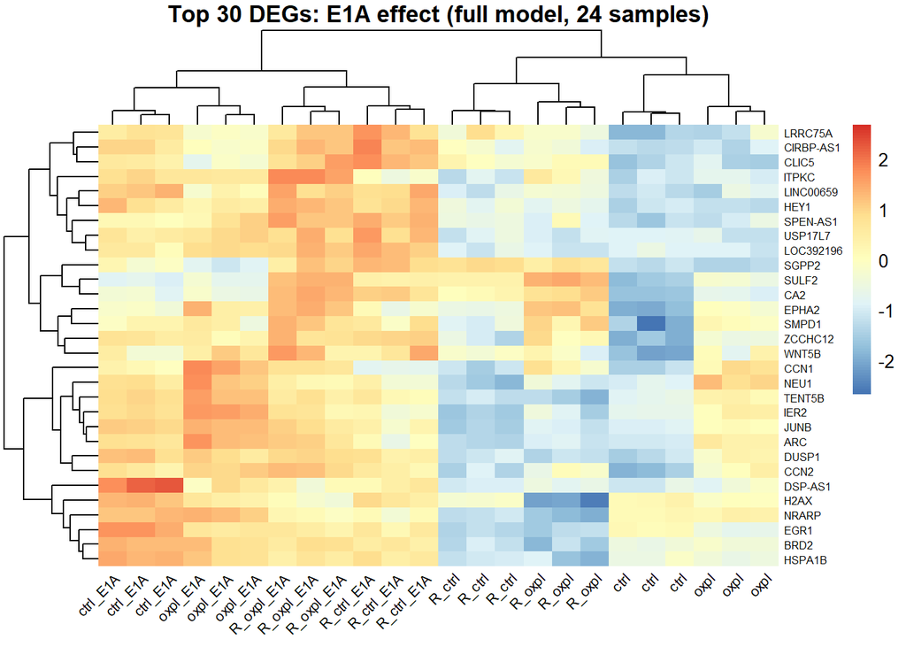

```r
plot_heatmap(
  res = res_E1A,
  vsd = vsd,
  col_labels = as.character(colData(dds)$stat),
  n_top = 30,
  title = "Top 30 DEGs: E1A effect (full model, 24 samples)"
)
```

On the heatmap, E1A-positive and E1A-negative samples form separate clusters, meaning that the E1A effect affects not just one gene, but the entire expression program.

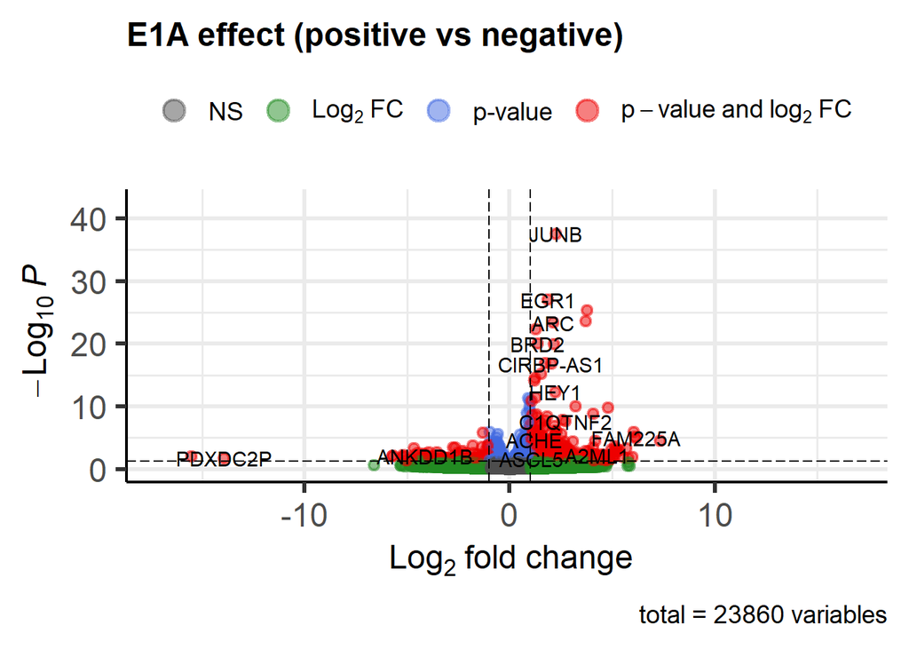

```r
plot_volcano(
  res = res_E1A,
  title = "E1A effect (positive vs negative)"
)
```

This profile is consistent with the fact that E1A is known as a protein that activates AP-1-dependent and other early transcriptional programs, including through interaction with p300/CBP

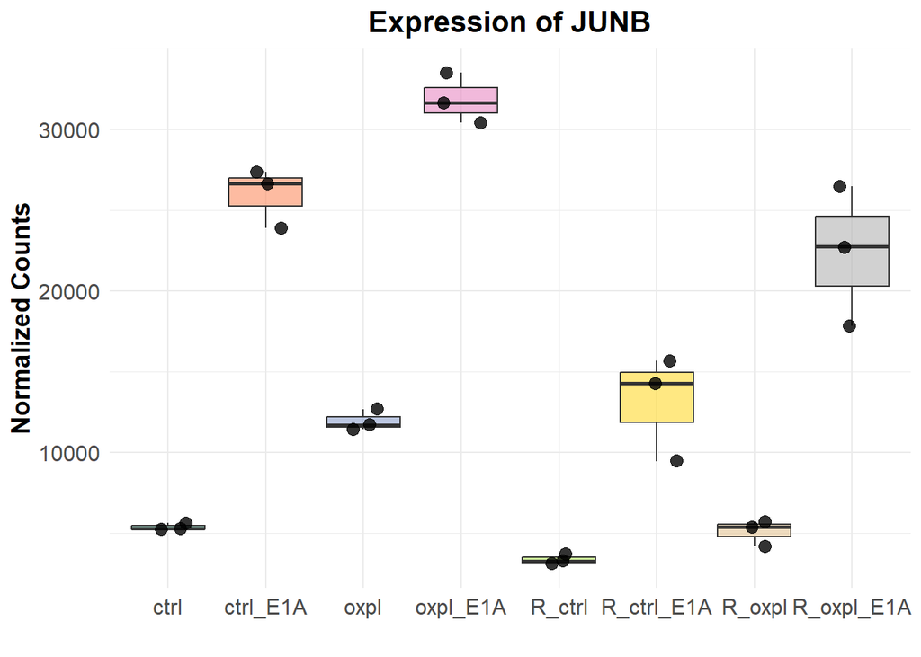

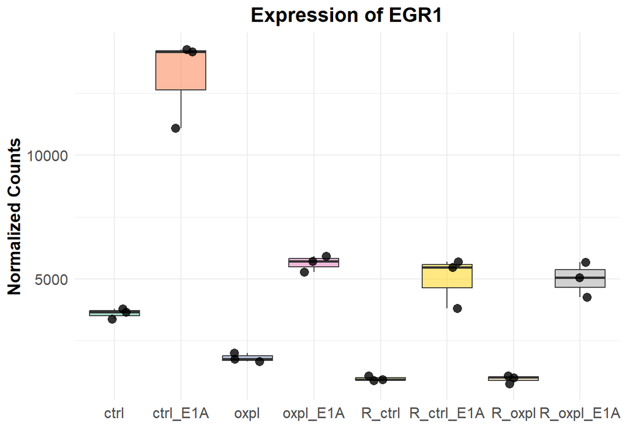

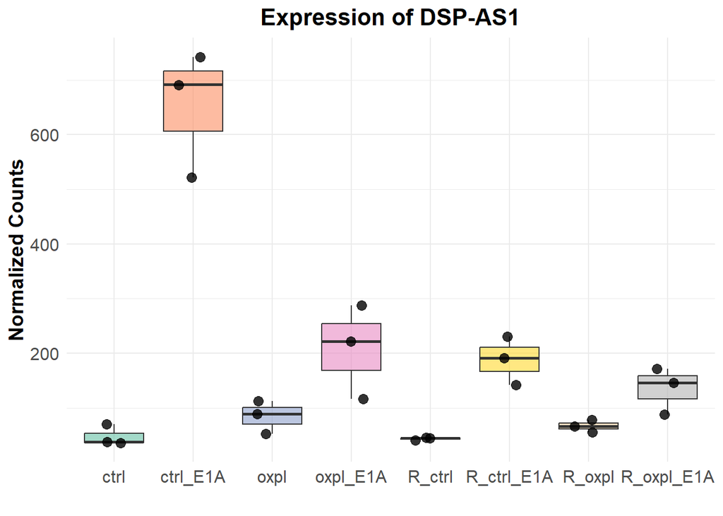

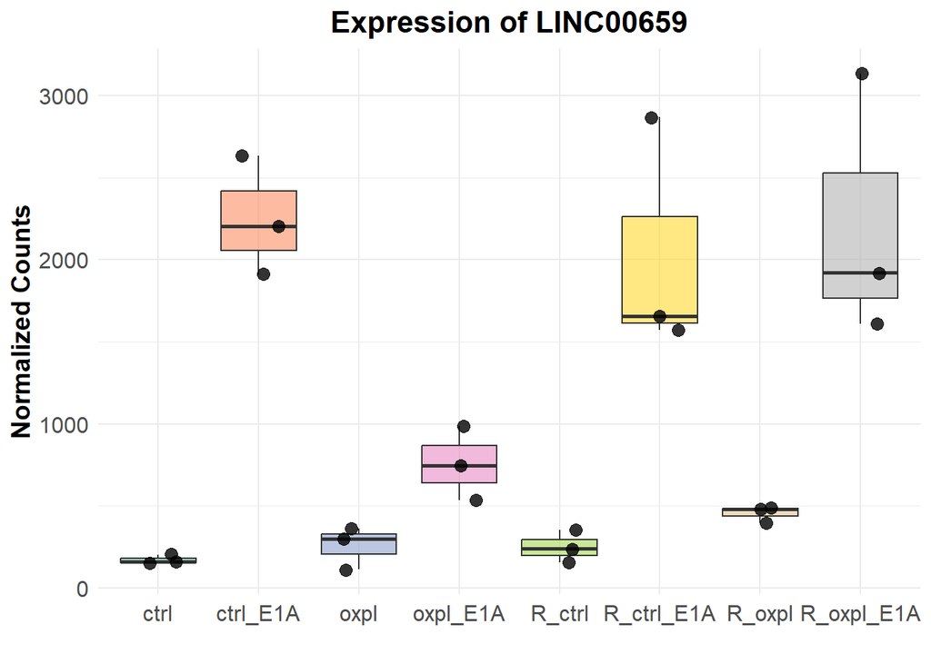

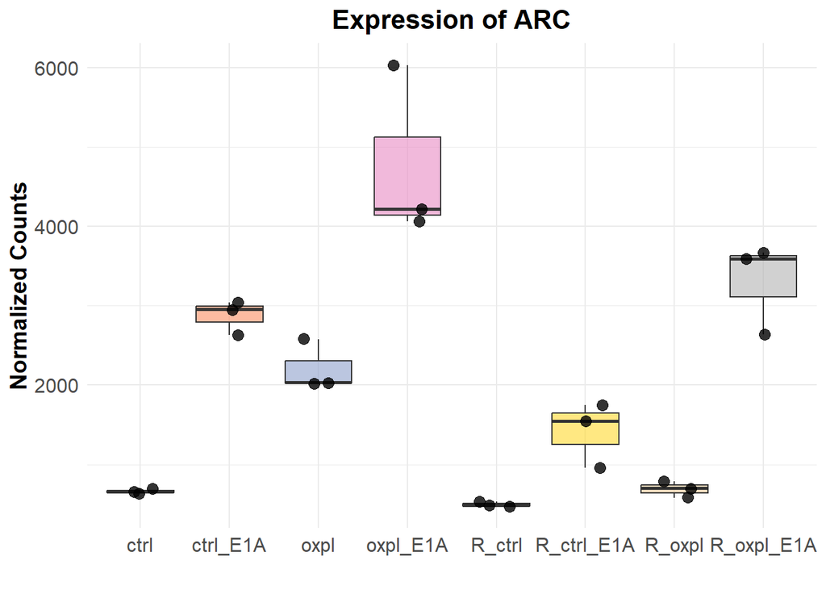

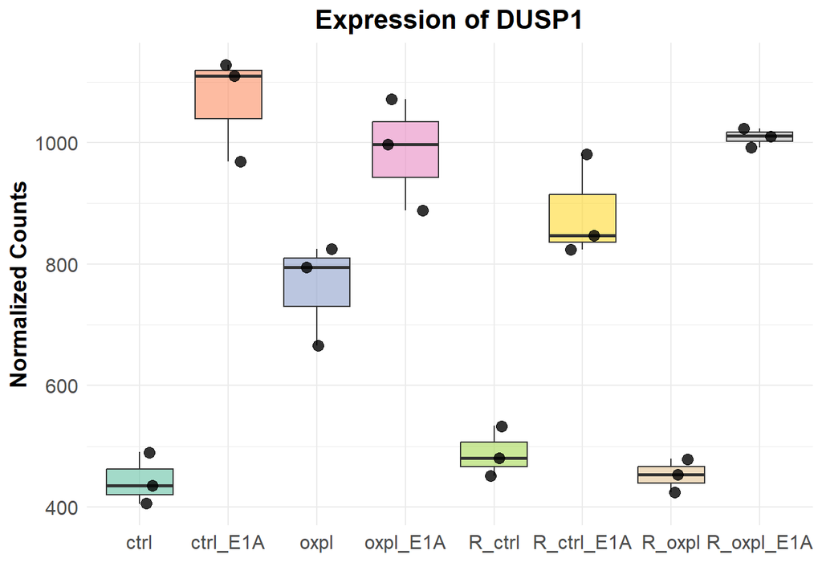

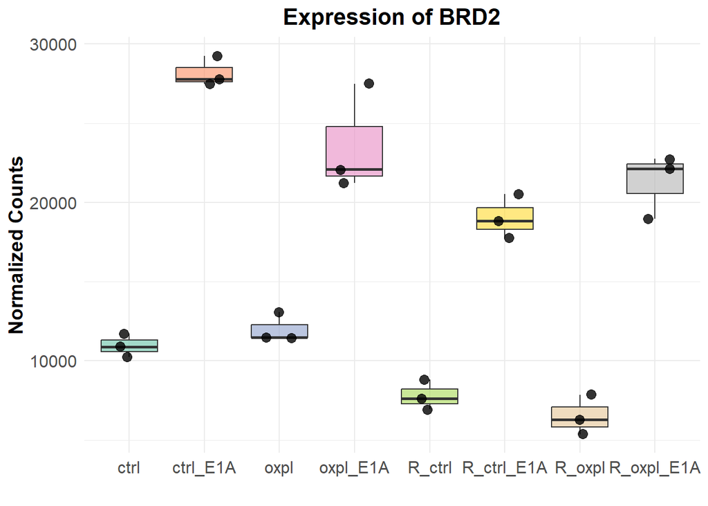

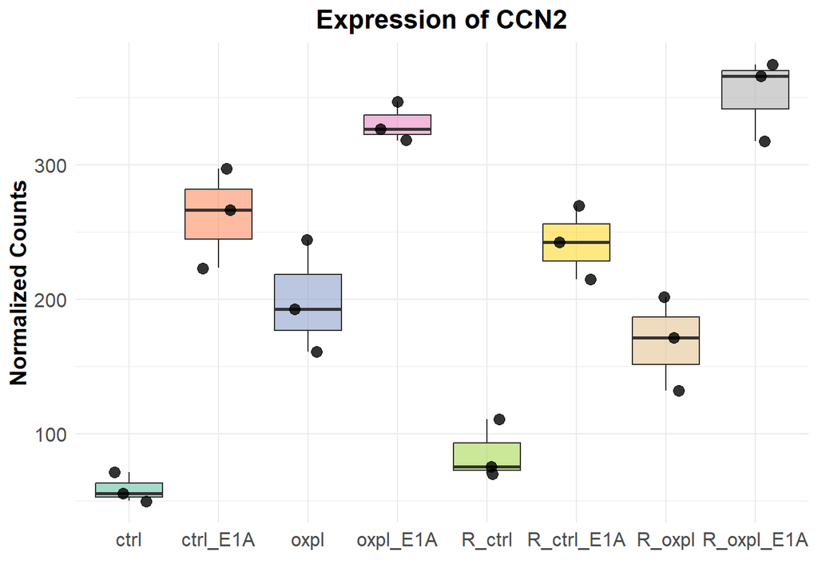

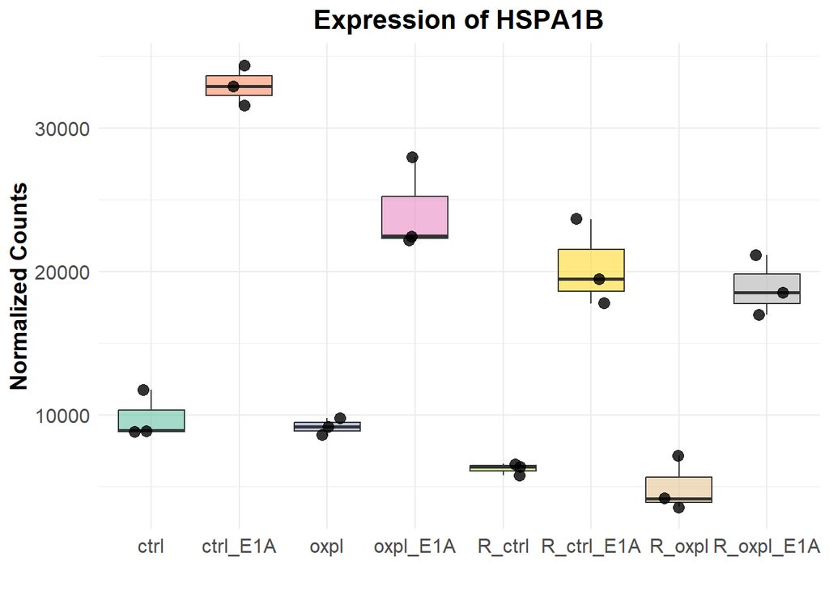

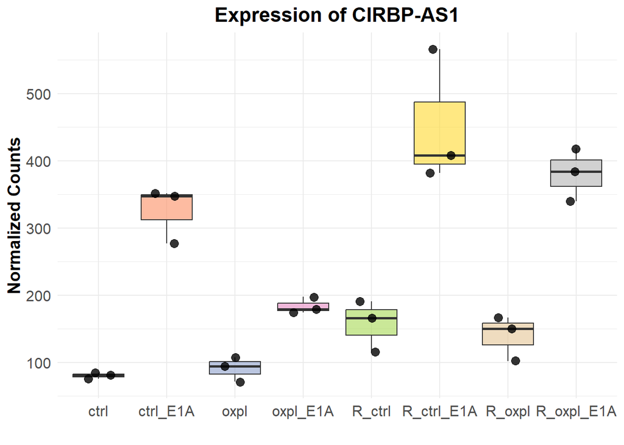

```r
# Top 10 genes by importance
top10_genes <- head(rownames(res_E1A)[order(res_E1A$padj)], 10)

for (gene in top10_genes) {
  ge <- plotCounts(dds, gene, intgroup = "stat", returnData = TRUE)

  p <- ggplot(ge, aes(x = stat, y = count, fill = stat)) +
    geom_boxplot(outlier.shape = NA, alpha = 0.6) +
    geom_jitter(width = 0.2, size = 3, alpha = 0.8) +
    scale_fill_brewer(palette = "Set2") +
    labs(title = paste("Expression of", gene),
         x = "", y = "Normalized Counts") +
    theme_minimal() +
    theme(legend.position = "none",
          axis.text = element_text(size = 12),
          axis.title = element_text(size = 14, face = "bold"),
          plot.title = element_text(size = 16, face = "bold", hjust = 0.5))

  print(p)
}
```

E1A strongly induces an immediate-early transcriptional program in HCT116 cells, centered on AP-1 and early response genes such as JUNB and EGR1, together with stress/adaptation and chromatin-regulatory factors like DUSP1, HSPA1B, BRD2, and CCN2.

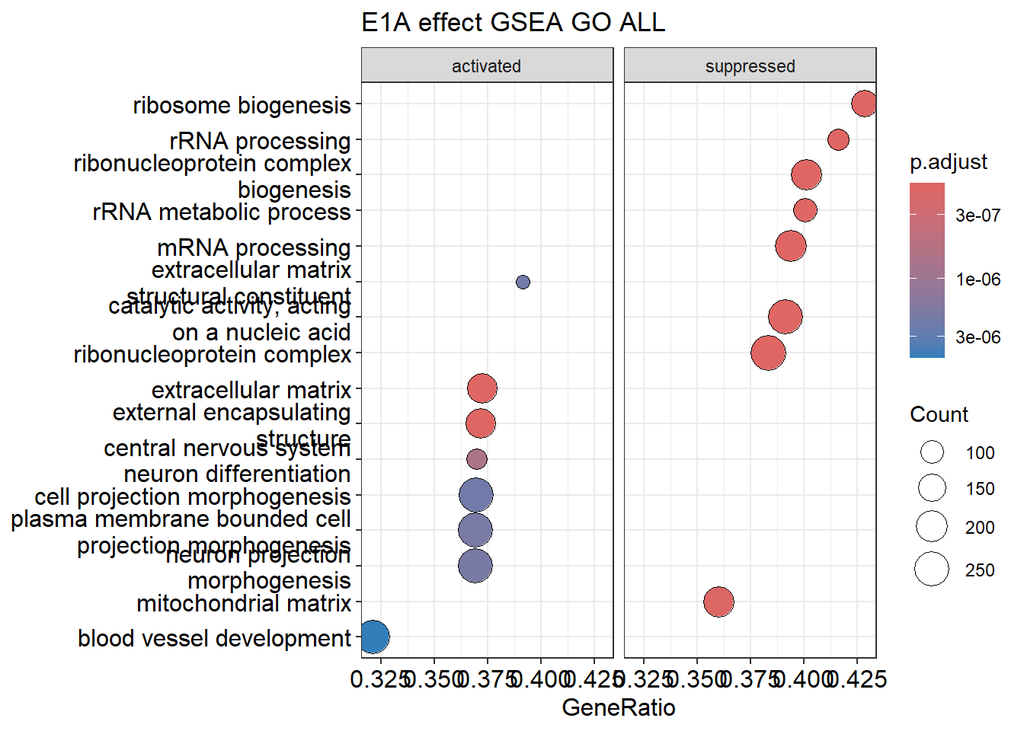

```r
# GSEA GO
gene_stat <- res_E1A$stat
names(gene_stat) <- rownames(res_E1A)
gene_stat <- na.omit(gene_stat)
gene_stat <- sort(gene_stat, decreasing = TRUE)

gsea_results <- run_gsea_go(gene_stat, title_prefix = "E1A effect")

print(gsea_results$p1)
```

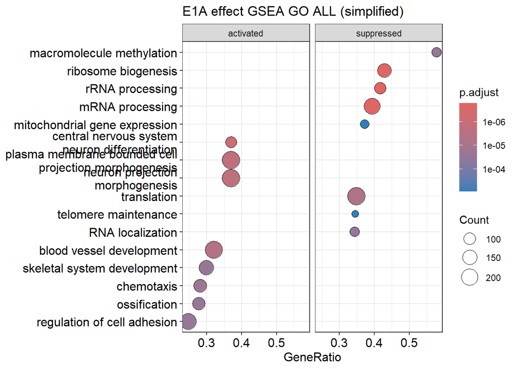

```r
print(gsea_results$p2)
```

GO GSEA analysis reveals that E1A suppresses ribosome biogenesis and rRNA processing, but activates extracellular matrix, neuron differentiation, cell projection morphogenesis, and blood vessel development. This indicates a pronounced reprogramming of the cellular state toward tissue remodeling and differentiation programs. The suppression of ribosome genesis can be explained as part of an antiproliferative program, since cancer cells require active ribosome biogenesis for rapid cell division. The enhancement of ECM- and differentiation-related pathways may be a sign that E1A disrupts the tumor transcriptional program, shifting the cell from a growth state to a state of remodeling and partial “de-oncogenization.”

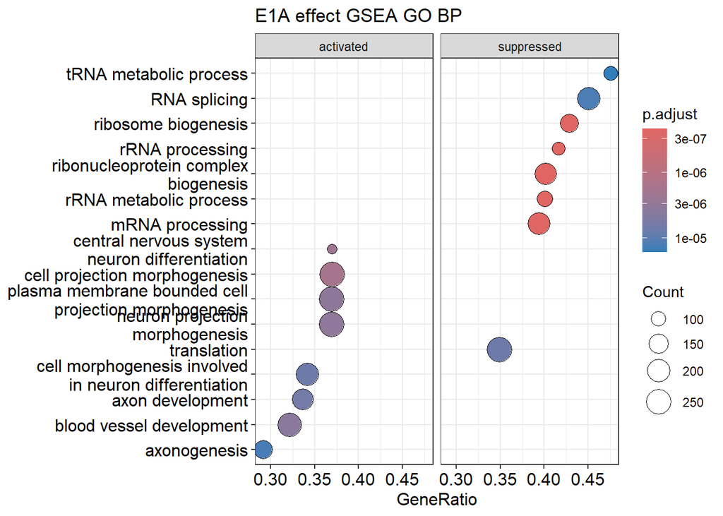

```r
# GO BP
res_bp <- run_gsea_go(gene_stat, ont = "BP", title_prefix = "E1A effect")
print(res_bp$p1)
```

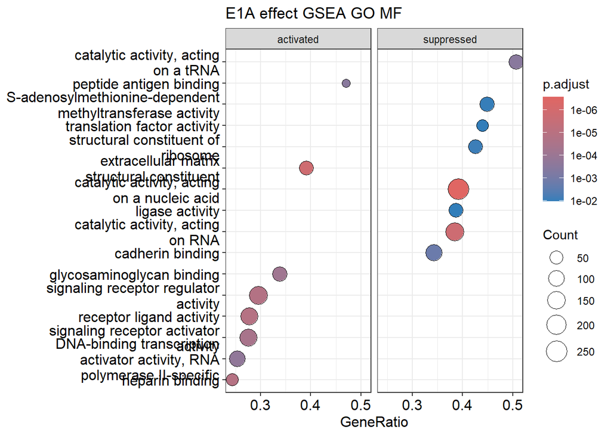

```r
# GO MF
res_mf <- run_gsea_go(gene_stat, ont = "MF", title_prefix = "E1A effect")
print(res_mf$p1)
```

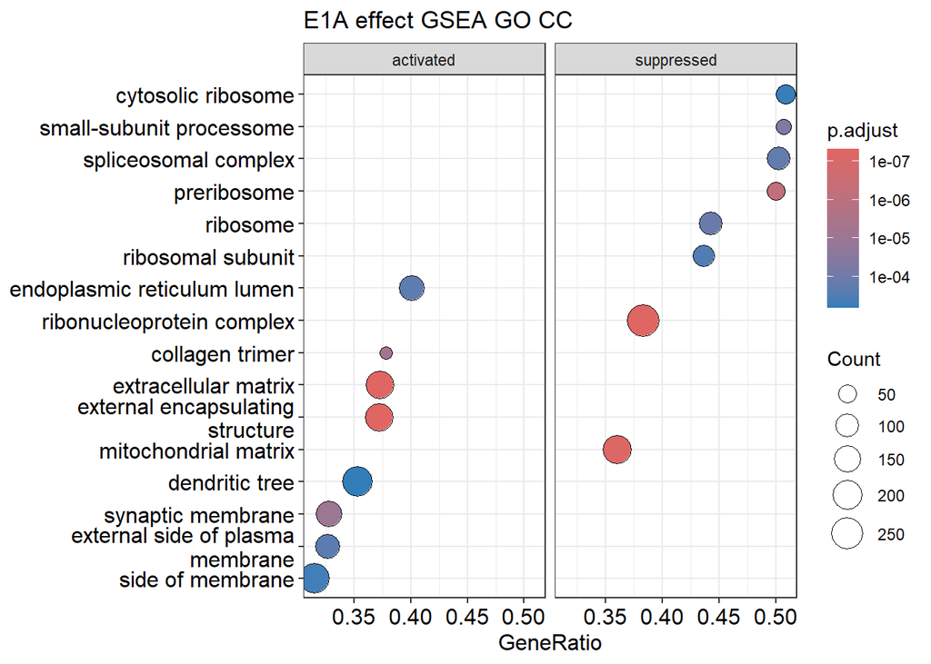

```r
# GO CC
res_cc <- run_gsea_go(gene_stat, ont = "CC", title_prefix = "E1A effect")
print(res_cc$p1)
```

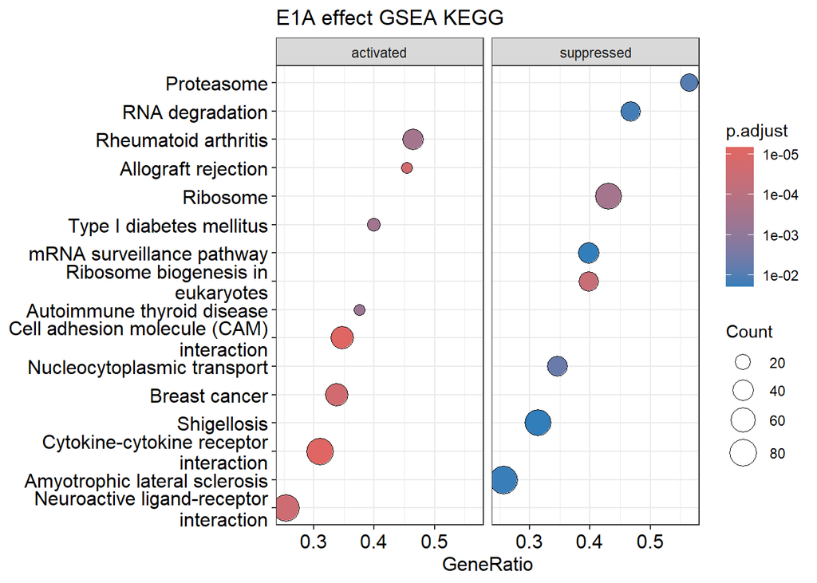

```r
# SYMBOL → ENTREZ
mapping_kegg <- mapIds(org.Hs.eg.db,
                       keys = names(gene_stat),
                       column = "ENTREZID",
                       keytype = "SYMBOL",
                       multiVals = "first")

# geneList with ENTREZ ID
gene_list_entrez <- gene_stat
names(gene_list_entrez) <- mapping_kegg
gene_list_entrez <- na.omit(gene_list_entrez)

# KEGG GSEA
kegg_results <- run_gsea_kegg(gene_list_entrez, title_prefix = "E1A effect")

print(kegg_results$plot)
```

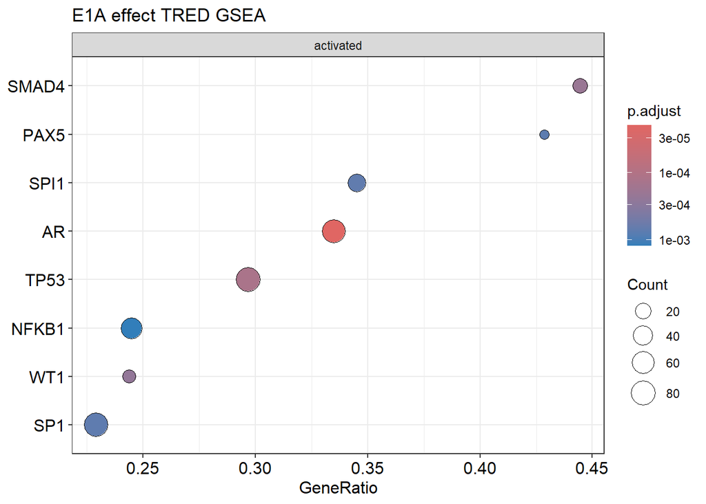

```r
# TRED GSEA
tred_results <- run_tred_gsea(gene_list_entrez, title_prefix = "E1A effect")

print(tred_results$dotplot)
```

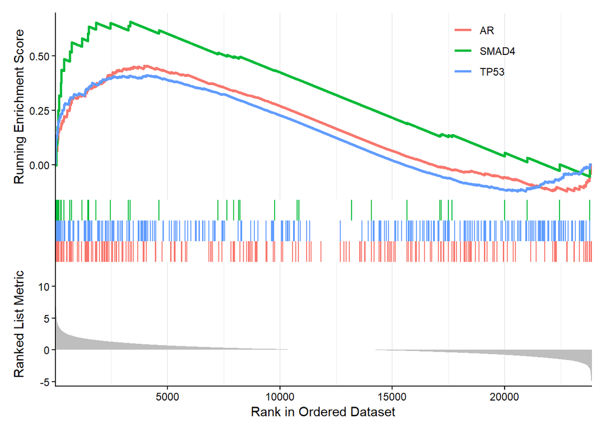

```r
print(tred_results$gseaplot)
```

```r
# ctrl vs dox+
keep <- colData(dds)$cell_line == "HCT116" & colData(dds)$condition == "ctrl"
dds_HCT116 <- dds[, keep]

table(dds_HCT116$e1a_status)
```

```
##
## negative positive
##        3        3
```

```r
#  e1a_status only
design(dds_HCT116) <- ~ e1a_status

# DESeq2
dds_HCT116 <- DESeq(dds_HCT116)

# e1a_status_positive_vs_negative
res_E1A_HCT116 <- results(dds_HCT116, name = "e1a_status_positive_vs_negative")
summary(res_E1A_HCT116)
```

```
##
## out of 20617 with nonzero total read count
## adjusted p-value < 0.1
## LFC > 0 (up)       : 764, 3.7%
## LFC < 0 (down)     : 1364, 6.6%
## outliers [1]       : 5, 0.024%
## low counts [2]     : 6342, 31%
## (mean count < 11)
## [1] see 'cooksCutoff' argument of ?results
## [2] see 'independentFiltering' argument of ?results
```

```r
# padj < 0.05 и |log2FC| > 1
up <- sum(res_E1A_HCT116$padj < 0.05 & res_E1A_HCT116$log2FoldChange > 1, na.rm = TRUE)
down <- sum(res_E1A_HCT116$padj < 0.05 & res_E1A_HCT116$log2FoldChange < -1, na.rm = TRUE)
cat("Up-regulated:", up, "\n")
```

```
## Up-regulated: 149
```

```r
cat("Down-regulated:", down, "\n")
```

```
## Down-regulated: 34
```

```r
cat("Total DEGs:", up + down, "\n")
```

```
## Total DEGs: 183
```

The effect of E1A is significantly stronger in sensitive HCT116 cells (183 DEGs) compared to the full model (117 DEGs). In HCT116, E1A not only activates but also represses many genes (34 downregulated), whereas in the full model, downregulation is minimal (8 downregulated). This indicates that the resistant cell line and/or oxaliplatin modify the response to E1A, attenuating its transcriptional effects.

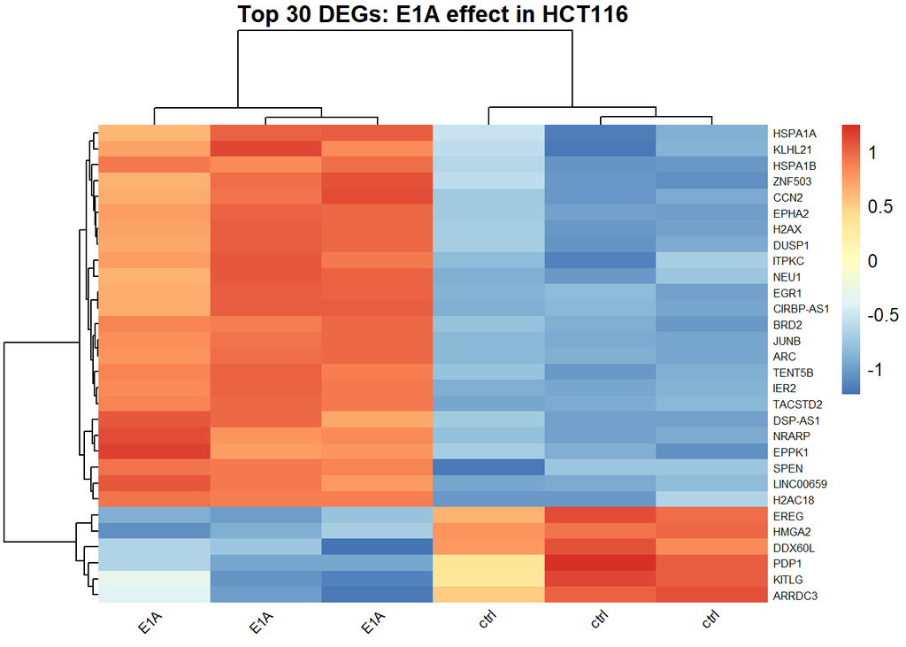

```r
vsd_HCT116 <- vst(dds_HCT116, blind = FALSE)

plot_heatmap(
  res = res_E1A_HCT116,
  vsd = vsd_HCT116,
  col_labels = ifelse(colData(dds_HCT116)$e1a_status == "negative", "ctrl", "E1A"),
  n_top = 30,
  title = "Top 30 DEGs: E1A effect in HCT116"
)
```

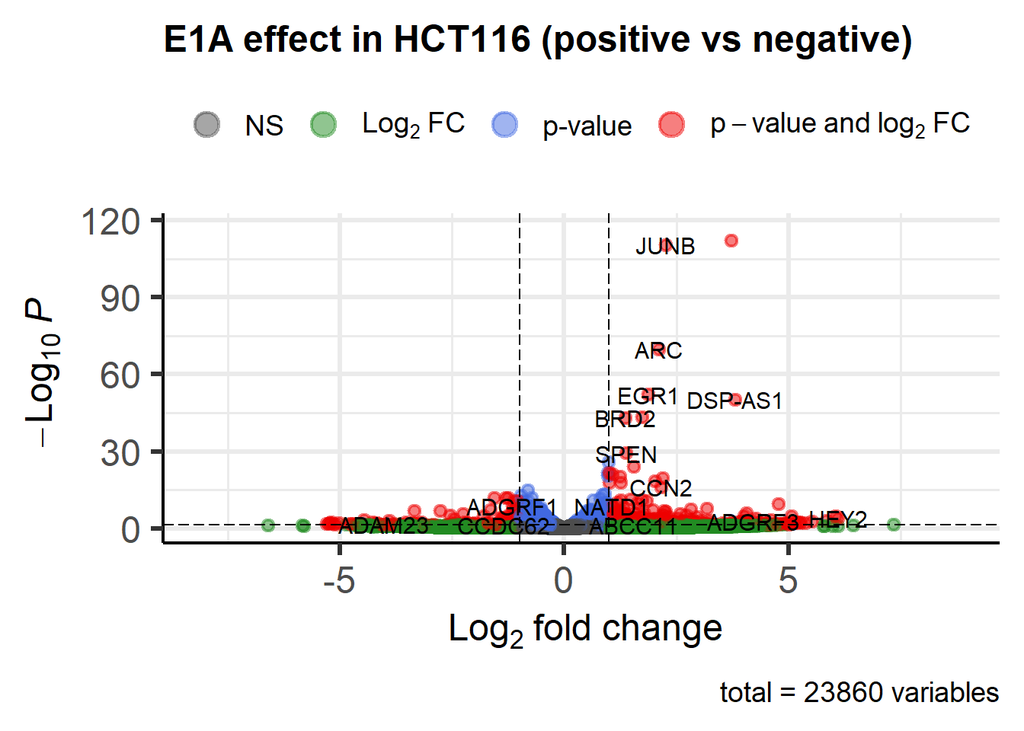

```r
plot_volcano(
  res = res_E1A_HCT116,
  title = "E1A effect in HCT116 (positive vs negative)"
)
```

In both models, E1A consistently activates the early response and AP-1-related program: JUNB, EGR1, ARC, and BRD2 are well-suited for this role. This means that, regardless of the background, E1A triggers rapid transcriptional rearrangements associated with stress, the immediate response, and the regulation of proliferation.

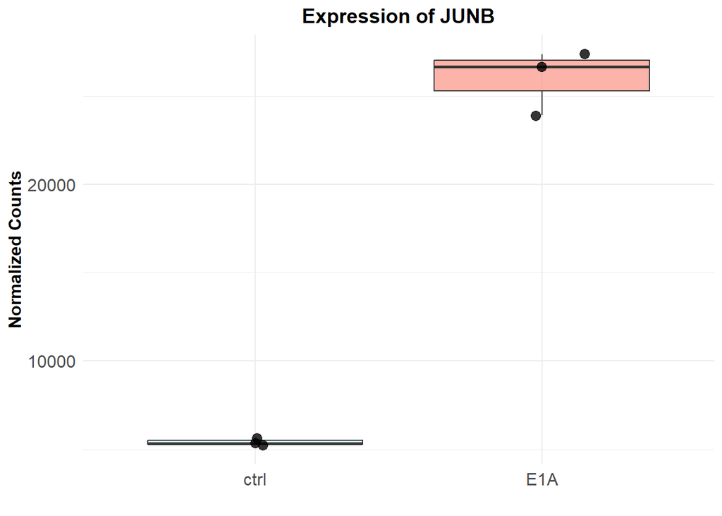

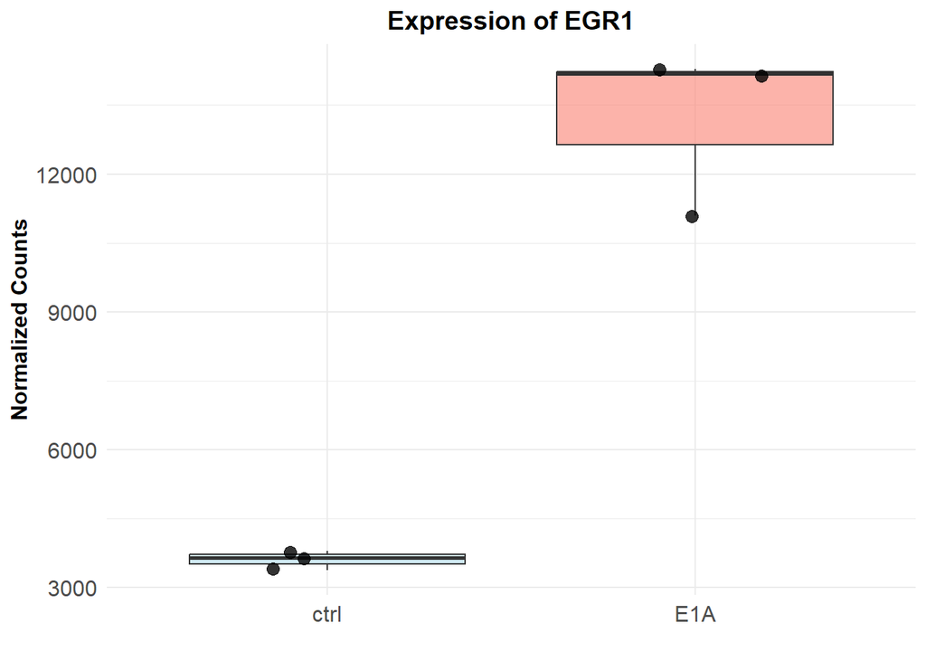

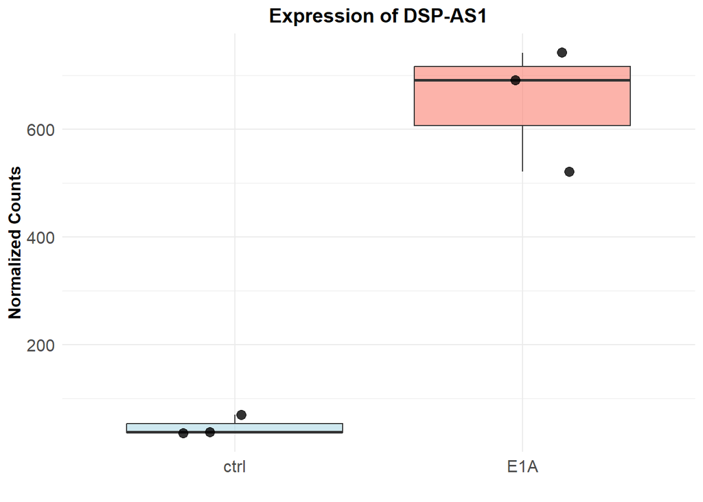

```r
genes_of_interest <- c("JUNB", "EGR1", "DSP-AS1")

for (gene in genes_of_interest) {
  ge <- plotCounts(dds_HCT116, gene, intgroup = "e1a_status", returnData = TRUE)

  ge$condition <- ifelse(ge$e1a_status == "negative", "ctrl", "E1A")

  p <- ggplot(ge, aes(x = condition, y = count, fill = condition)) +
    geom_boxplot(outlier.shape = NA, alpha = 0.6) +
    geom_jitter(width = 0.2, size = 3, alpha = 0.8) +
    scale_fill_manual(values = c("ctrl" = "lightblue", "E1A" = "salmon")) +
    labs(title = paste("Expression of", gene),
         x = "", y = "Normalized Counts") +
    theme_minimal() +
    theme(legend.position = "none",
          axis.text = element_text(size = 12),
          axis.title = element_text(size = 12, face = "bold"),
          plot.title = element_text(size = 14, face = "bold", hjust = 0.5))

  print(p)
}
```